## Librerias

```python
import numpy as np
import pandas as pd
import matplotlib.pyplot as plt
from sklearn.datasets import make_classification as MC
from sklearn.decomposition import PCA
from numpy import linalg as LA
import pprint
PP = pprint.PrettyPrinter(indent=4)
COLORS = ["#673AB7","#CDDC39","#E91E63","#FFEB3B","#2196F3","#FF9800"]
np.seterr(divide='ignore', invalid='ignore')
def Vector(*args):
    return np.array(args)
```

# Conjunto de datos

```python
getTrainPath = lambda i: "./data/iris_tr_{}c.csv".format(i)
getTestPath = lambda i: "./data/iris_tt_{}c.csv".format(i)

def getTrainAndTest(i):
#   Load training data sets
    dfs_train = [ pd.read_csv(getTrainPath(i),header=None) for i in range(2,4)]
#   Load test data sets.
    dfs_test  = [pd.read_csv(getTestPath(i),header=None) for i in range(2,4)]
#   (Clousure) Augment a matrix d x n => ( d + 1 ) x n
    def __getTrainAndTest(dfs):
        X     = dfs[i][1:].values
        y     = (dfs[i].values[0]-1).astype(int)
        ones  = np.ones(X.shape[1])
        X_aug = np.vstack([ones,X])
        return X_aug,y
    return [__getTrainAndTest(dfs_train),__getTrainAndTest(dfs_test)]


((X0_train,y0_train),(X0_test,y0_test)) = getTrainAndTest(0)
((X1_train,y1_train),(X1_test,y1_test)) = getTrainAndTest(1)
# X0_train.shape
```

[output not shown]

# Práctica #1: Regresión logística

a) Implementar el algoritmo de regresión logística usando la regla de actualización con descenso de gradiente.

## Función sigmoid o logit:

$$ p(y=1|\hat{x})=\frac{1}{1+exp(-\hat{\mathbf{w}}^{T}\mathbf{\hat{x}})} $$

```python
def sigmoid(x):
    return 1/(1+np.exp(-x))
```

## Descenso de gradiente

```python
def gradient_descent(X,y,**kwargs):
    LAMBDA       = kwargs.get("LAMBDA",1/(10**3))
    epochs       = kwargs.get("epochs",100)
    LR           = kwargs.get("learning_rate",0.001)
    threshold    = kwargs.get("threshold",1/(np.power(10,3)))
    show_entropy = kwargs.get("show_entropy",False)
    w            = np.random.rand(5).reshape(-1,1)
    predicate    =  True
    i            = 0

    while(predicate):
#       Linear discriminant function
        x                   = (w.T@X)
#       Mapping values to (0,1)
        _y                  = sigmoid(x)
#       Supervised learning
        yy                  = (_y-y)
#       Gradient
        delta_Lw            = X@(yy.T)
#       w(i) vector of weights at iteration k
        w_temp              = w
#       w(i+1) new vector of weights
        w                   = w-(LR*delta_Lw) + LAMBDA*w
#       cross - entropy
        Lw                  = cross_entropy_loss(w,y,_y,l=LAMBDA)
        if(show_entropy):
            print("[{}]- CROSS ENTROPY LOSS: {}".format(i,Lw))
#       check exit conditions: Max iteration reached or Convergence
        norm_diff           = LA.norm(np.abs(w_temp-w))
        max_iter_reached    = epochs-1<=i
        convergence_reached = norm_diff < threshold
        predicate = not(( max_iter_reached or convergence_reached ))
#       Increment the counter
        i+=1
    return {'w':w,
            'max_iter_reached':max_iter_reached,
            'convergence_reached':convergence_reached,
            "iterations":i
           }
```

### (B)

b) Aplicar la implementación en el inciso (a) para entrenar el vector de pesos w utilizando el conjunto de entrenamiento en el archivo $\textbf{iris_tr2c.csv}$. Se recomienda utilizar un número máximo de iteraciones $k_{max} = 100 \times 10^{3}$ y un valor de umbral de convergencia de $\theta = 1 × 10^{−3}$.

```python
k_max           = 100*np.power(10,3)
gradient_result = gradient_descent(X0_train,y0_train,epochs=k_max,LAMBDA=0,show_entropy=False)
__w             = gradient_result['w']
gradient_result
```

```
{'w': array([[-5.35113266],
        [-0.11904915],
        [-2.4570234 ],
        [ 5.53212628],
        [ 8.94158363]]),
 'max_iter_reached': False,
 'convergence_reached': True,
 'iterations': 5027}
```

### (C)

c) Clasifique los patrones de prueba en el archivo $\textbf{iris_tt_2c.csv}$ utilizando el vector de pesos w encontrado en el inciso (b).

```python
result_0  = (__w.T@X0_test > 0).astype(int)
result_0
```

```
array([[0, 0, 0, 0, 0, 1, 1, 1, 1, 1]])
```

```python
result_1  = (sigmoid(__w.T@X0_test)>0.5).astype(int)
result_1
```

```
array([[0, 0, 0, 0, 0, 1, 1, 1, 1, 1]])
```

Mida la tasa de aciertos en el conjunto de prueba (i.e., número de aciertos sobre el total de muestras de prueba).

```python
def get_accuracy(y_pred,y):
    return (y_pred==y).astype(int).sum()/y.shape[0]
"Tasa de aciertos: "+str(get_accuracy(result_0,y0_test))
```

```
'Tasa de aciertos: 1.0'
```

### (D)

d) Ejecute los incisos (b) y (c) variando tanto la tasa de aprendizaje.

$$η = [1 \times 10^{−1}, 1 \times 10^{−2}, 1 \times 10^{−3}, 1 \times 10^{−4}, 1 \times 10^{−5}, 1 \times 10^{−6}]$$

,

como el parámetro de regularización,

$$λ = [1 \times 10^{−1} , 1 \times 10^{−2} , 1 \times 10^{−3} , 1 \times 10^{−4} , 1 \times 10^{−5} , 1 \times 10{−6}]$$

```python
LRS        = [1/10,1/100,1/1000,1/10000,1/100000,1/1000000]
for LR0 in LRS:
    for LR1 in LRS:
        print("_"*100)
        print("\t\t\t\t\tTasa de aprendizaje: {} / Regularizacion: {}".format(LR0,LR1))
        print("_"*100)
        g0_result = gradient_descent(X0_train,y0_train,LAMBDA=LR1,learning_rate=LR0,epochs=k_max)
        ___w      = g0_result['w']
        pred    = ((g0_result['w'].T@X0_test) > 0).astype(int)
        g0_result['w'] = "["+','.join(g0_result['w'].astype(str).flatten().tolist())+"]"
        PP.pprint("Convergence reached: "+str(g0_result['convergence_reached']))
        PP.pprint("Max iterations reached: "+str(g0_result['max_iter_reached']))
        PP.pprint("Iterations: "+str(g0_result['iterations']))
        PP.pprint("Tasa de aciertos: "+str(get_accuracy(pred,y0_test)))
        print("y_predicted= "+str(pred.flatten()))
    #     PP.pprint("Predicciones: "+','.join(pred.astype(str).flatten().tolist()))
        print("_"*100)
#     print("\n")
```

```
____________________________________________________________________________________________________
					Tasa de aprendizaje: 0.1 / Regularizacion: 0.1
____________________________________________________________________________________________________
```

```
'Convergence reached: False'
'Max iterations reached: True'
'Iterations: 100000'
'Tasa de aciertos: 0.5'
y_predicted= [0 0 0 0 0 0 0 0 0 0]
____________________________________________________________________________________________________
____________________________________________________________________________________________________
					Tasa de aprendizaje: 0.1 / Regularizacion: 0.01
____________________________________________________________________________________________________
```

```
'Convergence reached: False'
'Max iterations reached: True'
'Iterations: 100000'
'Tasa de aciertos: 0.5'
y_predicted= [0 0 0 0 0 0 0 0 0 0]
____________________________________________________________________________________________________
____________________________________________________________________________________________________
					Tasa de aprendizaje: 0.1 / Regularizacion: 0.001
____________________________________________________________________________________________________
'Convergence reached: False'
'Max iterations reached: True'
'Iterations: 100000'
'Tasa de aciertos: 1.0'
y_predicted= [0 0 0 0 0 1 1 1 1 1]
____________________________________________________________________________________________________
____________________________________________________________________________________________________
					Tasa de aprendizaje: 0.1 / Regularizacion: 0.0001
____________________________________________________________________________________________________
'Convergence reached: False'
'Max iterations reached: True'
'Iterations: 100000'
'Tasa de aciertos: 1.0'
y_predicted= [0 0 0 0 0 1 1 1 1 1]
____________________________________________________________________________________________________
____________________________________________________________________________________________________
					Tasa de aprendizaje: 0.1 / Regularizacion: 1e-05
____________________________________________________________________________________________________
'Convergence reached: True'
'Max iterations reached: False'
'Iterations: 6751'
'Tasa de aciertos: 1.0'
y_predicted= [0 0 0 0 0 1 1 1 1 1]
____________________________________________________________________________________________________
____________________________________________________________________________________________________
					Tasa de aprendizaje: 0.1 / Regularizacion: 1e-06
____________________________________________________________________________________________________
'Convergence reached: True'
'Max iterations reached: False'
'Iterations: 6042'
'Tasa de aciertos: 1.0'
```

[output cut: 257 more lines]

```
'Convergence reached: True'
'Max iterations reached: False'
'Iterations: 1'
'Tasa de aciertos: 0.5'
y_predicted= [1 1 1 1 1 1 1 1 1 1]
____________________________________________________________________________________________________
____________________________________________________________________________________________________
					Tasa de aprendizaje: 1e-06 / Regularizacion: 1e-06
____________________________________________________________________________________________________
'Convergence reached: True'
'Max iterations reached: False'
'Iterations: 1'
'Tasa de aciertos: 0.5'
y_predicted= [1 1 1 1 1 1 1 1 1 1]
____________________________________________________________________________________________________
```

### E)

e) (Bonus). Graficar la función de entropía cruzada binaria (Clase AD-08, Ecuación 15) en función de las iteraciones para los diferentes valores de $η$ y $λ$.

```python
def cross_entropy_loss(w,yi,_yi,**kwargs):
    l = kwargs.get("l",0.001)
#     return -(yi*np.log(_yi)+(1-yi)*np.log(1-_yi)+((l/2) *LA.norm(w)**2)).sum()
    return -(yi*np.log(_yi)+(1-yi)*np.log(1-_yi)).sum()+((l/2) *LA.norm(w)**2)
```

```python
result = {}
ITERATIONS = range(1,101)
for i,LR in enumerate(LRS):
    for j,LR1 in enumerate(LRS):
        for iterations in ITERATIONS:
            _w_ = gradient_descent(X0_train,y0_train,epochs=iterations,learning_rate=LR,LAMBDA=LR1)['w']
            _y  = sigmoid(_w_.T@X0_train)
    #         print(_y.shape)
            cel = cross_entropy_loss(_w_,y0_train,_y)
            key = "{}_{}".format(LR,LR1)
            if not key in result:
                result[key] = Vector()
            result[key]= np.concatenate([result[key],Vector(cel)])

# result.shape
# Vector(result)
# result[0].shape
```

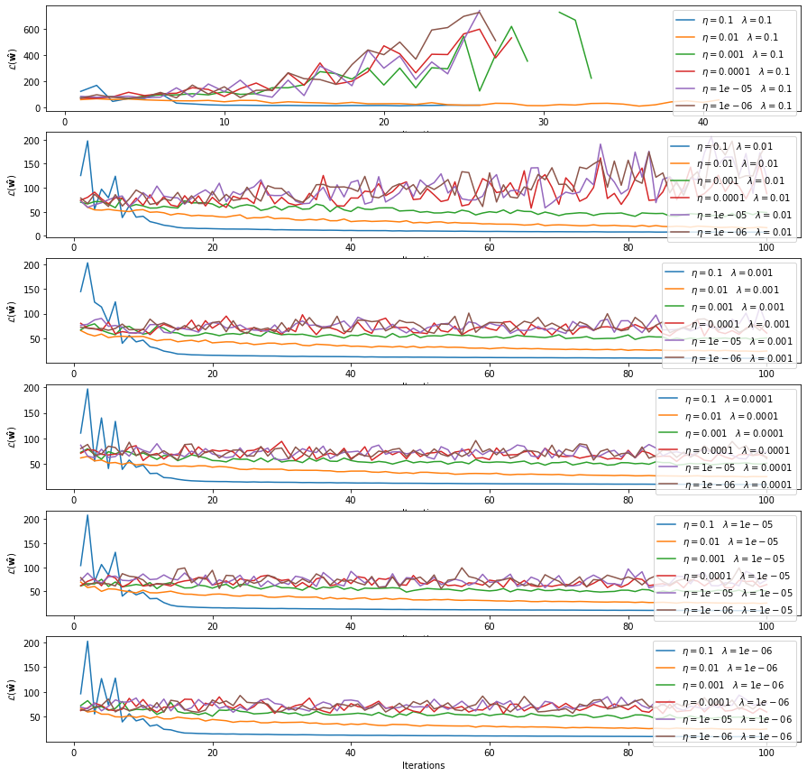

```python
_,ax=plt.subplots(6,figsize=(15 ,15))

for i,(key,v) in enumerate(result.items()):
    ax_index= i%6
    ax[ax_index].plot(ITERATIONS,v,label='$\eta = {} \quad \lambda = {}$'.format(*key.split("_")))
    ax[ax_index].set_ylabel("$\mathcal{L}(\mathbf{\hat{w}})$")
    ax[ax_index].set_xlabel("Iterations")
    ax[ax_index].legend()
# plt.savefig
```

# Práctica #2: Regresión softmax

### Softmax

a) Implementar el algoritmo de regresión softmax usando la regla de actualización con descenso de gradiente

Softmax:

$$ \hat{y}_{ij} = \frac{\text{exp}(\mathbf{\hat{w}^T\hat{x}_i} )}{\sum_{l=1}^{c} \text{exp}(\mathbf{\hat{w}_{l}^{T} \hat{x}_{i} })} $$

```python
# Softmax for a specific class
def _softmax(xi,ws,i):
    denominator = Vector(*list(map(lambda wi:np.exp(wi.T@xi),ws.T))).sum()
    return np.exp(ws[:,i].T@xi) /denominator
# Calculate softmax for c classes.
def __softmax(X,ws,**kwargs):
    c = kwargs.get("c",3)
    results = []
    for xi in X:
        results.append(Vector(*list(map(lambda i: _softmax(xi,ws,i),range(c)))))
    return Vector(*results)
```

### Función de entropía cruzada categórica

$$ \mathcal{L}(\mathbf{\hat{w_{1}},....,\hat{w_{c}}}) = - \sum_{i=1}^{n} \sum_{j=1}^{c} y_{ij}ln(\hat{y}_{ij}) $$

```python
def categorical_cross_entropy(X,Y,W):
    return -(Y*np.log(__softmax(X.T,W))).sum()
```

### One-hot enconding

```python
def toOneHotEncoding(y):
    vLen   = np.unique(y).shape[0]
    def __change(yi):
        tmp     = np.zeros(vLen)
        tmp[yi] = 1
        return tmp.astype(int)
    oneHot = Vector(*list(map(__change,y)))
    return oneHot
```

### Decenso de grandiente

```python
def gradient_descent_multi(X,y,**kwargs):
    epochs     = kwargs.get("epochs",100)
    LR         = kwargs.get("learning_rate",0.001)
    threshold  = kwargs.get("threshold",1/(np.power(10,3)))
    LAMBDA     = kwargs.get("l",0.0001)
#     W          = np.random.rand(d,c)
    W          = np.zeros([X.shape[0],3])
    Y1_train   = toOneHotEncoding(y)
    i = 0
    predicate=True
    Lws = []
    while predicate:
        _Y       = __softmax(X.T,W)
        delta_Lw = X@(_Y-Y1_train)
        W_k      = W
        W        = (W_k - LR*delta_Lw) + (LAMBDA*W_k)
        Lw       = categorical_cross_entropy(X,Y1_train,W)
        Lws.append(Lw)

        norm     = LA.norm(W_k-W,axis=0)
        convergence_reached = np.all(norm<threshold)
        max_iter_reached    =  epochs<=i
        predicate = not(( max_iter_reached or convergence_reached ))

        i+=1
    return [W,convergence_reached,max_iter_reached,i]
```

### B2)

b) Aplicar la implementación en el inciso (a) para entrenar la matriz de pesos W utilizando el conjunto de entrenamiento en el archivo iris_tr*3c.csv. Se recomienda utilizar un número máximo de iteraciones $k*{max} = 100 \times 10^{3}$ y un valor de umbral de convergencia de $\theta = 1 \times 10^{−3}$.

```python
%time
GD_1 = lambda learning_rate,threshold,LAMBDA: gradient_descent_multi(
    X1_train,
    y1_train,
    learning_rate=learning_rate,
    LAMBDA=LAMBDA,
    threshold=threshold,
    epochs=1000
)
_W_,cr,mir,_ = GD_1(0.001,LRS[2],0.000)
```

```
CPU times: user 2 µs, sys: 1e+03 ns, total: 3 µs
Wall time: 5.01 µs
```

### C2)

c) Clasifique los patrones de prueba en el archivo iris_tt_3c.csv utilizando la matriz de pesos W encontrada en el inciso (b). Para la clasificación, usar alguna de las reglas de decisión en la Diapositiva 21 (Clase AD08).

```python
decisionRule = lambda X,W : np.argmax(__softmax(X.T,W),axis=1)
y_pred = decisionRule(X1_test,_W_)
```

Mida la tasa de aciertos en el conjunto de prueba (i.e., número de aciertos sobre el total de muestras de prueba)

```python
"Tasa de aciertos: "+ str(get_accuracy(y1_test,y_pred))
```

```
'Tasa de aciertos: 0.9333333333333333'
```

d) Ejecute los incisos (b) y (c) variando tanto la tasa de aprendizaje,

$$η = [1 \times 10^{−1}, 1 \times 10^{−2}, 1 \times 10^{−3}, 1 \times 10^{−4}, 1 \times 10^{−5}, 1 \times 10^{−6}]$$

,

como el parámetro de regularización,

$$λ = [1 \times 10^{−1} , 1 \times 10^{−2} , 1 \times 10^{−3} , 1 \times 10^{−4} , 1 \times 10^{−5} , 1 \times 10^{−6}]$$

```python
for LR in LRS:
    for LR1 in LRS:
        _W,cr,mr,iterations = GD_1(LR,0.001,LR1)
        print("_"*100)
        print("\t\t\t\t\tTasa de aprendizaje: {} / Regularizacion: {}".format(LR,LR1))
        print("_"*100)
        pred    = decisionRule(X1_test,_W)
        print(pred)
        PP.pprint("Convergence reached: "+str(cr))
        PP.pprint("Max iterations reached: "+str(mr))
        PP.pprint("iterations: "+str(iterations))
        PP.pprint("Tasa de aciertos: "+ str(get_accuracy(y1_test,pred)))
    #     print("y_predicted= "+str(pred.flatten()))
    #     PP.pprint("Predicciones: "+','.join(pred.astype(str).flatten().tolist()))
        print("_"*100)
#     print("\n")
```

```
____________________________________________________________________________________________________
					Tasa de aprendizaje: 0.1 / Regularizacion: 0.1
____________________________________________________________________________________________________
[0 0 0 0 0 1 1 1 1 1 2 2 2 1 2]
'Convergence reached: False'
'Max iterations reached: True'
'iterations: 1001'
'Tasa de aciertos: 0.9333333333333333'
____________________________________________________________________________________________________
____________________________________________________________________________________________________
					Tasa de aprendizaje: 0.1 / Regularizacion: 0.01
____________________________________________________________________________________________________
[0 0 0 0 0 1 1 1 1 1 2 2 2 1 2]
'Convergence reached: False'
'Max iterations reached: True'
'iterations: 1001'
'Tasa de aciertos: 0.9333333333333333'
____________________________________________________________________________________________________
____________________________________________________________________________________________________
					Tasa de aprendizaje: 0.1 / Regularizacion: 0.001
____________________________________________________________________________________________________
[0 0 0 0 0 1 1 1 1 1 2 2 2 1 2]
'Convergence reached: False'
'Max iterations reached: True'
'iterations: 1001'
'Tasa de aciertos: 0.9333333333333333'
____________________________________________________________________________________________________
____________________________________________________________________________________________________
					Tasa de aprendizaje: 0.1 / Regularizacion: 0.0001
____________________________________________________________________________________________________
[0 0 0 0 0 1 1 1 1 1 2 2 2 1 2]
'Convergence reached: False'
'Max iterations reached: True'
'iterations: 1001'
'Tasa de aciertos: 0.9333333333333333'
____________________________________________________________________________________________________
____________________________________________________________________________________________________
					Tasa de aprendizaje: 0.1 / Regularizacion: 1e-05
____________________________________________________________________________________________________
[0 0 0 0 0 1 1 1 1 1 2 2 2 1 2]
```

[output cut: 269 more lines]

```
[2 2 2 2 2 2 2 2 2 2 2 2 2 2 2]
'Convergence reached: True'
'Max iterations reached: False'
'iterations: 1'
'Tasa de aciertos: 0.3333333333333333'
____________________________________________________________________________________________________
____________________________________________________________________________________________________
					Tasa de aprendizaje: 1e-06 / Regularizacion: 1e-06
____________________________________________________________________________________________________
[2 2 2 2 2 2 2 2 2 2 2 2 2 2 2]
'Convergence reached: True'
'Max iterations reached: False'
'iterations: 1'
'Tasa de aciertos: 0.3333333333333333'
____________________________________________________________________________________________________
```

### E2)

e) (Bonus). Graficar la función de entropía cruzada categórica (Clase AD-08, Ecuación 19) en función de las iteraciones para los diferentes valores de $η$ y $λ$.

```python
result = {}
ITERATIONS = range(1,100)
yij   = toOneHotEncoding(y1_train)
for i,LR in enumerate(LRS):
    for LR1 in enumerate(LRS):
        for iterations in ITERATIONS:
            _w_,_,_,_ = gradient_descent_multi(
                X1_train,
                y1_train,
                epochs=iterations,
                learning_rate=LR,
                LAMBDA=LR1
            )
            _y    = __softmax(X1_train.T,_w_)
            Lw    = (yij*np.log(_y)).sum()
            key = "{}_{}".format(LR,LR1)
            if not key in result:
                result[key] = Vector()
            result[key]= np.concatenate([result[key],Vector(Lw)])
```

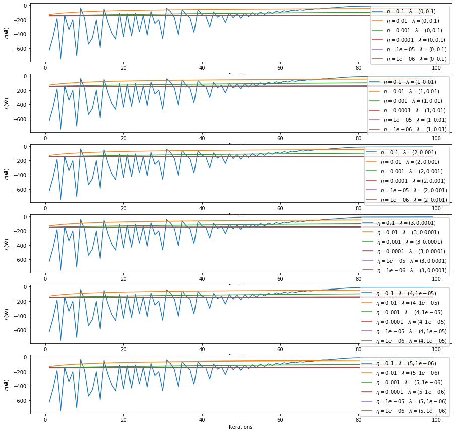

```python
_,ax=plt.subplots(6,figsize=(15 ,15))

for i,(key,v) in enumerate(result.items()):
    ax_index= i%6
    ax[ax_index].plot(ITERATIONS,v,label='$\eta = {} \quad \lambda = {}$'.format(*key.split("_")))
    ax[ax_index].set_ylabel("$\mathcal{L}(\mathbf{\hat{w}})$")
    ax[ax_index].set_xlabel("Iterations")
    ax[ax_index].legend()
```

```python
_y    = __softmax(X1_train.T,_W_)
_y.shape
```

```
(135, 3)
```

## Función lineal discriminante

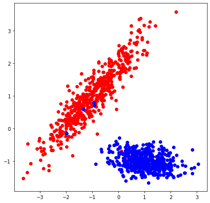

```python
%matplotlib inline
X,y = MC(n_samples=1000,n_features=2,n_informative=2, n_redundant=0,n_clusters_per_class=1)
w0  = X[np.argwhere(y==0).flatten()]
w1  = X[np.argwhere(y==1).flatten()]
plot2D(w0,w1)
```

```python
def plot2D(w0,w1):
    _,ax = plt.subplots(figsize=(7,7))
    ax.scatter(w0[:,0],w0[:,1],color="red")
    ax.scatter(w1[:,0],w1[:,1],color="blue")
```

## Normalizacion

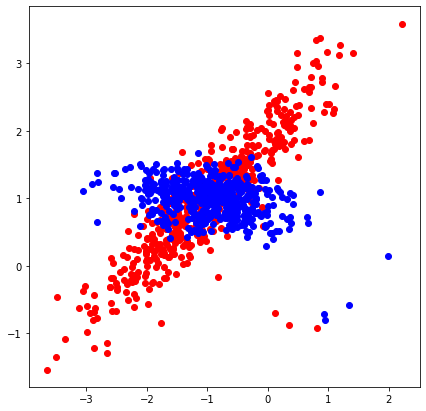

```python
_w1=-w1
plot2D(w0,_w1)
```

```python
XW   = np.concatenate([w0,_w1]).T
ones = np.ones(XW.shape[1])
XW   = np.vstack([ones,XW])
```

## Decesnso de gradiente

```python
def cost_fn(X,w):
    return (-w.T@X).sum()
def GD(X,**kwargs):
    w             = np.zeros(X.shape[0]).reshape(-1,1)
    lr            = kwargs.get('learning_rate',0.001)
    epochs        = kwargs.get('epochs',100)
    show_progress = kwargs.get('show_progress',False )
    jpws          = []
    for i in range(epochs):
        gxs       = w.T@X
        mask0     = (gxs >0).T.flatten()
        mask1     = (gxs <=0).T.flatten()
        _X_       = X[:,mask1]
        Jpw       = cost_fn(_X_,w)
        jpws.append(Jpw)
        delta_Jpw = _X_.sum()
        w         = w + (lr*delta_Jpw)
        if(show_progress):
            print("[{}] Jpw = {}".format(i,Jpw))
    return w,jpws
_w, jpws = GD(XW,epochs=10000,learning_rate=0.00001)
_w
```

```
array([[0.00951129],
       [0.00951129],
       [0.00951129]])
```

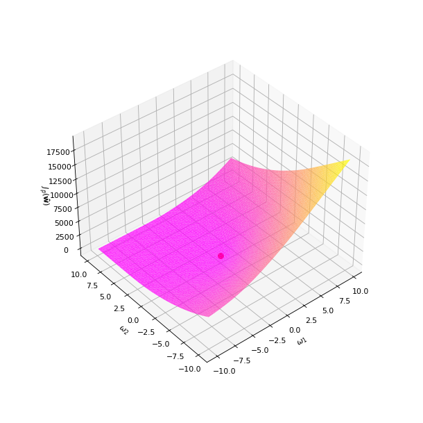

```python
%matplotlib notebook
fig = plt.figure(figsize=(7,7))
ax = fig.add_subplot(111, projection='3d')
xLim = 10
step = 0.3
x = np.arange(-xLim, xLim, step)
y = np.arange(-xLim,xLim, step)
XX, YY = np.meshgrid(x, y)
XY     = toOrderedPair(XX,YY)
result = []
for ws in XY:
    ws = ws.reshape(-1,1)
    ws = np.vstack([np.ones(1),ws])
    gxs       = ws.T@XW
    mask1     = (gxs <=0).T.flatten()
    _X_       = XW[:,mask1]
    jpw = cost_fn(_X_,ws)
    result.append(jpw)
Z = np.array(result)
Z = Z.reshape(XX.shape[0],YY.shape[0])
# ax.plot_wireframe(XX,YY,Z,color="red")
# ax.plot_surface(XX,YY,Z,color="pink")
ax.plot_trisurf(XX.flatten(),YY.flatten(),Z.flatten(),cmap="spring",alpha=.8)
ax.scatter(_w[1],_w[2],np.min(jpws),color="red",s=50,alpha=1)
ax.set_xlabel("$\omega_1$")
ax.set_ylabel("$\omega_2$")
ax.set_zlabel("$J_{p}(\mathbf{\hat{w}})$")
```

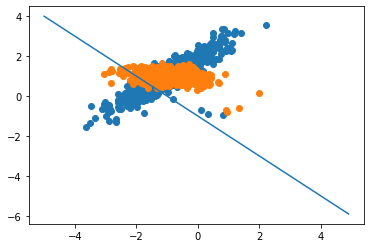

```python
%matplotlib inline
# %matplotlib notebook
fig  = plt.figure()
ax   = fig.add_subplot()
_w0 = w0
__w1 = _w1
Wi  = np.concatenate([_w0,__w1])
for wi in [_w0,__w1]:
    ax.scatter(wi[:,0],wi[:,1])

def fx(w):
    return lambda x: ((-(w[0] / w[2]) / (w[0] / w[1]))*x + (-w[0] / w[2]))
x = np.arange(-5,5,0.1)
y = fx(_w)(x)
ax.plot(x,y)
# _w
```

```python
def toOrderedPair(X,Y):
    xShape= X.shape
    yShape= Y.shape
#     print(xShape,yShape)
    return np.dstack([X,Y]).reshape(xShape[0]*yShape[0],2)
```